# Buoy Project Report-Group 10

Chenghao Meng,Yinfeng Zhou and Feng Fan

2020/9/25

## 1 Data Collection

```r
library(tidyverse)
```

```r
# Make URLs
url_1 = "http://www.ndbc.noaa.gov/view_text_file.php?filename=mlrf1h"
url_2 = ".txt.gz&dir=data/historical/stdmet/"

years = c(1987:2019)
urls = str_c(url_1, years, url_2, sep = "")
filenames = str_c("mr", years, sep = "")
```

```r
n = length(years)
# Read the data on the website
for (i in 1:n){
   suppressMessages(
    assign(filenames[i], read_table2(urls[i], col_names = TRUE)
  ))
}
```

### 1.1 Bind the Data from 1987-1999

```r
# Bind the data from 1987-1999

for (i in 1987:1998){
  if (i==1987)
    mr_pre<-mr1987
  else
    mr_pre = rbind(mr_pre,get(str_c("mr",i,sep = "")))
}
# Change the row name
names(mr_pre)[names(mr_pre) == "YY"] = "YYYY"

mr87_99 = rbind(mr_pre,mr1999)
if(mr87_99$YYYY<100){
    mr87_99$YYYY = mr87_99$YYYY + 1900
  }
head(mr87_99)
```

```
## # A tibble: 6 x 16
##    YYYY MM    DD    hh    WD    WSPD  GST    WVHT   DPD   APD   MWD BAR    ATMP
##   <dbl> <chr> <chr> <chr> <chr> <chr> <chr> <dbl> <dbl> <dbl> <dbl> <chr>  <chr>
## 1  1987 12    04    12    275   06.2  06.9     99    99    99   999 1018.6 20
## 2  1987 12    04    13    273   06.5  07.3     99    99    99   999 1019   20.2
## 3  1987 12    04    14    271   05.6  06.2     99    99    99   999 1019.3 20.5
## 4  1987 12    04    15    285   06.1  07.3     99    99    99   999 1019.1 20.8
## 5  1987 12    04    16    283   07.2  08.1     99    99    99   999 1018.8 21.1
## 6  1987 12    04    17    283   08.8  09.6     99    99    99   999 1017.5 21.3
## # ... with 3 more variables: WTMP <dbl>, DEWP <dbl>, VIS <dbl>
```

### 1.2 Bind the Data from 2000 to 2006

```r
for (i in 2000:2004){
    if (i==2000)
    mr00_06<-mr2000
    else
    mr00_06 = rbind(mr00_06,get(str_c("mr",i,sep = "")))
}
head(mr00_06)
```

```
## # A tibble: 6 x 17
##    YYYY MM    DD    hh       WD  WSPD   GST  WVHT   DPD   APD   MWD   BAR  ATMP
##   <dbl> <chr> <chr> <chr> <dbl> <dbl> <dbl> <dbl> <dbl> <dbl> <dbl> <dbl> <dbl>
## 1  2000 01    01    00       96   4.5   5      99    99    99   999 1020.  23.7
## 2  2000 01    01    01       86   4.4   5      99    99    99   999 1021.  23.7
## 3  2000 01    01    02       96   5.3   6.1    99    99    99   999 1021   23.6
## 4  2000 01    01    03       85   5.4   5.9    99    99    99   999 1021.  23.6
## 5  2000 01    01    04       86   6.3   6.7    99    99    99   999 1021.  23.5
## 6  2000 01    01    05       87   5.9   6.3    99    99    99   999 1021.  23.5
## # ... with 4 more variables: WTMP <dbl>, DEWP <dbl>, VIS <dbl>, TIDE <chr>
```

```r
mr_pre_2 = rbind(mr2005,mr2006)
mr_pre_2 = subset(mr_pre_2, select = -c(mm))
mr00_06 = rbind(mr00_06,mr_pre_2)
tail(mr00_06)
```

```
## # A tibble: 6 x 17
##    YYYY MM    DD    hh       WD  WSPD   GST  WVHT   DPD   APD   MWD   BAR  ATMP
##   <dbl> <chr> <chr> <chr> <dbl> <dbl> <dbl> <dbl> <dbl> <dbl> <dbl> <dbl> <dbl>
## 1  2006 12    31    18      116   9.2   9.8    99    99    99   999 1021.  25.1
## 2  2006 12    31    19      109   7.7   9      99    99    99   999 1020.  25
## 3  2006 12    31    20      106   6.8   8.1    99    99    99   999 1020.  25.2
## 4  2006 12    31    21      102   7.7   8.4    99    99    99   999 1020.  25.1
## 5  2006 12    31    22       99   8     9.1    99    99    99   999 1020.  25.2
## 6  2006 12    31    23      103   7.1   7.8    99    99    99   999 1020   25.2
## # ... with 4 more variables: WTMP <dbl>, DEWP <dbl>, VIS <dbl>, TIDE <chr>
```

```r
for (i in 2011:2019){
  if(i==2011)
    mr11_19<-mr2011
  else
    mr11_19 = rbind(mr11_19,get(str_c("mr",i,sep = "")))
}
names(mr11_19)[names(mr11_19) == "#YY"] = "YYYY"
mr11_19 = subset(mr11_19, select = -c(mm))
mr11_19 = mr11_19[-1,] # Delete the row with #YY etc.
head(mr11_19)
```

```
## # A tibble: 6 x 17
##   YYYY  MM    DD    hh    WDIR  WSPD  GST   WVHT  DPD   APD   MWD   PRES   ATMP
##   <chr> <chr> <chr> <chr> <chr> <chr> <chr> <chr> <chr> <chr> <chr> <chr>  <chr>
## 1 2011  01    01    00    86    9.9   11.1  99.00 99.00 99.00 999   1020.5 22.3
## 2 2011  01    01    01    110   10.8  12.5  99.00 99.00 99.00 999   1020.9 22.3
## 3 2011  01    01    02    112   10.2  11.4  99.00 99.00 99.00 999   1021.3 22.3
## 4 2011  01    01    03    107   11.2  13.4  99.00 99.00 99.00 999   1021.3 22.4
## 5 2011  01    01    04    114   10.7  11.5  99.00 99.00 99.00 999   1021.2 22.2
## 6 2011  01    01    05    123   10.6  11.4  99.00 99.00 99.00 999   1020.8 22.0
## # ... with 4 more variables: WTMP <chr>, DEWP <chr>, VIS <chr>, TIDE <chr>
```

### 1.4 Bind the Data from 2007 to 2010

```r
mr_pre_3 = rbind(mr2007,mr2009)
mr_pre_4 = rbind(mr2008,mr2010)

mr07_10 = rbind(mr_pre_3,mr_pre_4)
names(mr07_10)[names(mr07_10) == "#YY"] = "YYYY"
mr07_10 = subset(mr07_10, select = -c(mm))
mr07_10 = mr07_10[-1,] # Delete the row with #YY etc.
head(mr07_10)
```

```
## # A tibble: 6 x 17
##   YYYY  MM    DD    hh    WDIR  WSPD  GST   WVHT  DPD   APD   MWD   PRES   ATMP
##   <chr> <chr> <chr> <chr> <chr> <chr> <chr> <chr> <chr> <chr> <chr> <chr>  <chr>
## 1 2007  01    01    00    101   7.3   8.0   99.00 99.00 99.00 999   1020.5 25.2
## 2 2007  01    01    01    100   6.4   7.5   99.00 99.00 99.00 999   1021.0 25.2
## 3 2007  01    01    02    97    5.8   6.5   99.00 99.00 99.00 999   1021.3 25.2
## 4 2007  01    01    03    114   7.1   7.9   99.00 99.00 99.00 999   1021.3 25.3
## 5 2007  01    01    04    118   9.3   10.2  99.00 99.00 99.00 999   1021.0 25.4
## 6 2007  01    01    05    119   9.9   10.6  99.00 99.00 99.00 999   1020.4 25.1
## # ... with 4 more variables: WTMP <chr>, DEWP <chr>, VIS <chr>, TIDE <chr>
```

Now we conmapre the differences in column names between mr98_99 and mr00_06.

```r
colnames(mr87_99)
```

```
##  [1] "YYYY" "MM"   "DD"   "hh"   "WD"   "WSPD" "GST"  "WVHT" "DPD"  "APD"
## [11] "MWD"  "BAR"  "ATMP" "WTMP" "DEWP" "VIS"
```

```r
colnames(mr00_06)
```

```
##  [1] "YYYY" "MM"   "DD"   "hh"   "WD"   "WSPD" "GST"  "WVHT" "DPD"  "APD"
## [11] "MWD"  "BAR"  "ATMP" "WTMP" "DEWP" "VIS"  "TIDE"
```

We do some adjustments and bind them to get the data from 1987 to 2006.

```r
# Add TIDE to mr87_99
mr87_99$TIDE = c(rep(NA, times=nrow(mr87_99)))
# Check the colnames of mr_1
mr_1 = rbind(mr87_99,mr00_06)
colnames(mr_1)
```

```
##  [1] "YYYY" "MM"   "DD"   "hh"   "WD"   "WSPD" "GST"  "WVHT" "DPD"  "APD"
## [11] "MWD"  "BAR"  "ATMP" "WTMP" "DEWP" "VIS"  "TIDE"
```

### 1.5 Bind the Data from 2007 to 2019

```r
mr_2 = rbind(mr07_10,mr11_19)
colnames(mr_2)
```

```
##  [1] "YYYY" "MM"   "DD"   "hh"   "WDIR" "WSPD" "GST"  "WVHT" "DPD"  "APD"
## [11] "MWD"  "PRES" "ATMP" "WTMP" "DEWP" "VIS"  "TIDE"
```

```r
PRES = c(rep(NA, times=nrow(mr_1)))
mr_1 = cbind(mr_1[,1:11],PRES,mr_1[,12:ncol(mr_1)])
head(mr_1)
```

```
##   YYYY MM DD hh  WD WSPD  GST WVHT DPD APD MWD PRES    BAR ATMP WTMP DEWP VIS
## 1 1987 12 04 12 275 06.2 06.9   99  99  99 999   NA 1018.6   20 25.8  999  99
## 2 1987 12 04 13 273 06.5 07.3   99  99  99 999   NA   1019 20.2 25.8  999  99
## 3 1987 12 04 14 271 05.6 06.2   99  99  99 999   NA 1019.3 20.5 25.8  999  99
## 4 1987 12 04 15 285 06.1 07.3   99  99  99 999   NA 1019.1 20.8 25.8  999  99
## 5 1987 12 04 16 283 07.2 08.1   99  99  99 999   NA 1018.8 21.1 25.7  999  99
## 6 1987 12 04 17 283 08.8 09.6   99  99  99 999   NA 1017.5 21.3 25.6  999  99
##   TIDE
## 1 <NA>
## 2 <NA>
## 3 <NA>
## 4 <NA>
## 5 <NA>
## 6 <NA>
```

```r
BAR = c(rep(NA, times=nrow(mr_2)))
mr_2 = cbind(mr_2[,1:12],BAR,mr_2[,13:ncol(mr_2)])
names(mr_2)[names(mr_2) == "WDIR"] = "WD"
head(mr_2)
```

```
##   YYYY MM DD hh  WD WSPD  GST  WVHT   DPD   APD MWD   PRES BAR ATMP WTMP  DEWP
## 1 2007 01 01 00 101  7.3  8.0 99.00 99.00 99.00 999 1020.5  NA 25.2 25.7 999.0
## 2 2007 01 01 01 100  6.4  7.5 99.00 99.00 99.00 999 1021.0  NA 25.2 25.7 999.0
## 3 2007 01 01 02  97  5.8  6.5 99.00 99.00 99.00 999 1021.3  NA 25.2 25.6 999.0
## 4 2007 01 01 03 114  7.1  7.9 99.00 99.00 99.00 999 1021.3  NA 25.3 25.6 999.0
## 5 2007 01 01 04 118  9.3 10.2 99.00 99.00 99.00 999 1021.0  NA 25.4 25.7 999.0
## 6 2007 01 01 05 119  9.9 10.6 99.00 99.00 99.00 999 1020.4  NA 25.1 25.6 999.0
##    VIS  TIDE
## 1 99.0 99.00
## 2 99.0 99.00
## 3 99.0 99.00
## 4 99.0 99.00
## 5 99.0 99.00
## 6 99.0 99.00
```

### 1.6 Get the Data from 1987 to 2019

So we bind mr_1 and mr_2 to get data from 1987-2019.

```r
mr = rbind(mr_1,mr_2)
head(mr)
```

```
##   YYYY MM DD hh  WD WSPD  GST WVHT DPD APD MWD PRES    BAR ATMP WTMP DEWP VIS
## 1 1987 12 04 12 275 06.2 06.9   99  99  99 999 <NA> 1018.6   20 25.8  999  99
## 2 1987 12 04 13 273 06.5 07.3   99  99  99 999 <NA>   1019 20.2 25.8  999  99
## 3 1987 12 04 14 271 05.6 06.2   99  99  99 999 <NA> 1019.3 20.5 25.8  999  99
## 4 1987 12 04 15 285 06.1 07.3   99  99  99 999 <NA> 1019.1 20.8 25.8  999  99
## 5 1987 12 04 16 283 07.2 08.1   99  99  99 999 <NA> 1018.8 21.1 25.7  999  99
## 6 1987 12 04 17 283 08.8 09.6   99  99  99 999 <NA> 1017.5 21.3 25.6  999  99
##   TIDE
## 1 <NA>
## 2 <NA>
## 3 <NA>
## 4 <NA>
## 5 <NA>
## 6 <NA>
```

```r
# Download the file
write.table(mr,file="C:/Users/CH.Meng/Desktop/buoy.txt",row.names=FALSE,col.names=TRUE,sep = ",")
```

Now we finish the data collection.

## 2 Exploratory Data Analysis

### 2.1 Summary of the Dataset

Before making summary of the data, data type of certain columns should be transformed to numeric data.

```r
# Data type transformation
for (i in 5:ncol(mr))
  suppressMessages(
    mr[,i] <- as.numeric(mr[,i])
    )
```

Since “9999”,“999” and “99” in the dataset provide us with no specific information, we will replace those with NA.

```r
for (i in 1:ncol(mr))
  mr[,i][which(mr[,i]==9999|mr[,i]==999|mr[,i]==99)] = NA
```

Now we can have the summary of the dataset-mr, which will be transformed to tibble.

```r
# Summary of mr_tib
mr_tib = as_tibble(mr)
summary(mr_tib)
```

```
##      YYYY                MM                 DD                 hh
##  Length:260067      Length:260067      Length:260067      Length:260067
##  Class :character   Class :character   Class :character   Class :character
##  Mode  :character   Mode  :character   Mode  :character   Mode  :character
##
##
##
##
##        WD             WSPD             GST              WVHT
##  Min.   :  0.0   Min.   : 0.000   Min.   : 0.000   Min.   : NA
##  1st Qu.: 80.0   1st Qu.: 3.800   1st Qu.: 4.200   1st Qu.: NA
##  Median :117.0   Median : 5.800   Median : 6.400   Median : NA
##  Mean   :139.3   Mean   : 5.971   Mean   : 6.704   Mean   :NaN
##  3rd Qu.:183.0   3rd Qu.: 8.000   3rd Qu.: 8.900   3rd Qu.: NA
##  Max.   :360.0   Max.   :33.500   Max.   :41.000   Max.   : NA
##  NA's   :4418    NA's   :2697     NA's   :4309     NA's   :260067
##       DPD              APD              MWD              PRES
##  Min.   : NA      Min.   : NA      Min.   : NA      Min.   : 984.7
##  1st Qu.: NA      1st Qu.: NA      1st Qu.: NA      1st Qu.:1014.9
##  Median : NA      Median : NA      Median : NA      Median :1017.0
##  Mean   :NaN      Mean   :NaN      Mean   :NaN      Mean   :1017.0
##  3rd Qu.: NA      3rd Qu.: NA      3rd Qu.: NA      3rd Qu.:1019.2
##  Max.   : NA      Max.   : NA      Max.   : NA      Max.   :1032.2
##  NA's   :260067   NA's   :260067   NA's   :260067   NA's   :176655
##       BAR              ATMP            WTMP            DEWP
##  Min.   : 982.3   Min.   : 1.80   Min.   :15.90   Min.   : NA
##  1st Qu.:1014.6   1st Qu.:23.50   1st Qu.:24.70   1st Qu.: NA
##  Median :1016.8   Median :25.60   Median :26.60   Median : NA
##  Mean   :1016.8   Mean   :25.16   Mean   :26.68   Mean   :NaN
##  3rd Qu.:1018.9   3rd Qu.:28.00   3rd Qu.:29.00   3rd Qu.: NA
##  Max.   :1033.9   Max.   :39.50   Max.   :32.10   Max.   : NA
##  NA's   :98832    NA's   :1825    NA's   :3157    NA's   :260067
##       VIS              TIDE
##  Min.   : NA      Min.   : NA
##  1st Qu.: NA      1st Qu.: NA
##  Median : NA      Median : NA
##  Mean   :NaN      Mean   :NaN
##  3rd Qu.: NA      3rd Qu.: NA
##  Max.   : NA      Max.   : NA
##  NA's   :260067   NA's   :260067
```

From the summary, we can see that there is no much variation in column WVHT, DPD, APD, MWD, DEWP, VIS and TIDE, and column PRES and BAR also contains a lot of NA’s.

Since those columns cannot provide us with a lot of information, we will drop them for further analysis.

```r
# Drop the columns
mr_tib2 = mr_tib %>%
  select(-WVHT, -DPD, -APD, -MWD, -DEWP, -VIS,
         -TIDE,-PRES,-BAR)
dim(mr_tib2)
```

```
## [1] 260067      9
```

```r
# Summary of mr_tib2
summary(mr_tib2)
```

```
##      YYYY                MM                 DD                 hh
##  Length:260067      Length:260067      Length:260067      Length:260067
##  Class :character   Class :character   Class :character   Class :character
##  Mode  :character   Mode  :character   Mode  :character   Mode  :character
##
##
##
##
##        WD             WSPD             GST              ATMP
##  Min.   :  0.0   Min.   : 0.000   Min.   : 0.000   Min.   : 1.80
##  1st Qu.: 80.0   1st Qu.: 3.800   1st Qu.: 4.200   1st Qu.:23.50
##  Median :117.0   Median : 5.800   Median : 6.400   Median :25.60
##  Mean   :139.3   Mean   : 5.971   Mean   : 6.704   Mean   :25.16
##  3rd Qu.:183.0   3rd Qu.: 8.000   3rd Qu.: 8.900   3rd Qu.:28.00
##  Max.   :360.0   Max.   :33.500   Max.   :41.000   Max.   :39.50
##  NA's   :4418    NA's   :2697     NA's   :4309     NA's   :1825
##       WTMP
##  Min.   :15.90
##  1st Qu.:24.70
##  Median :26.60
##  Mean   :26.68
##  3rd Qu.:29.00
##  Max.   :32.10
##  NA's   :3157
```

### 2.2 Imputation of the Dataset

First, we will make histograms to explore the distribution of the columns.

#### 2.2.1 Histograms of the Columns

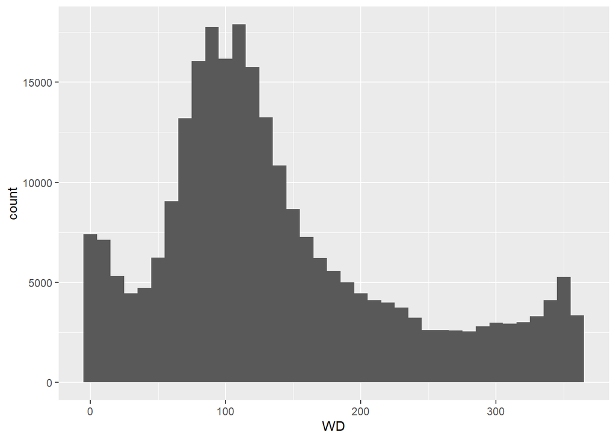

```r
# Hist. of WD
ggplot(data = mr_tib2) +
  geom_histogram(mapping = aes(x=WD),binwidth = 10)
```

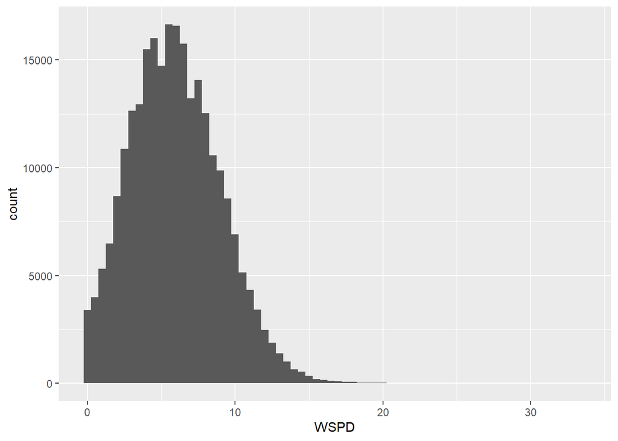

```r
# Hist. of WSPD
ggplot(data = mr_tib2) +
  geom_histogram(mapping = aes(x=WSPD),binwidth = 0.5)
```

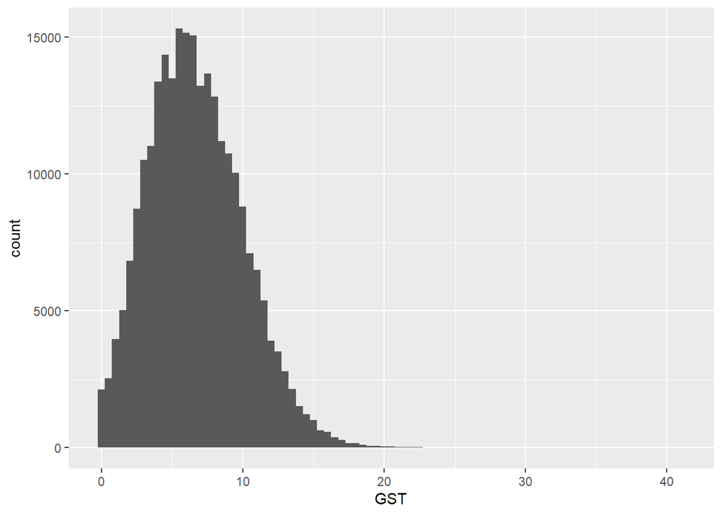

```r
# Hist. of GST
ggplot(data = mr_tib2) +
  geom_histogram(mapping = aes(x=GST),binwidth = 0.5)
```

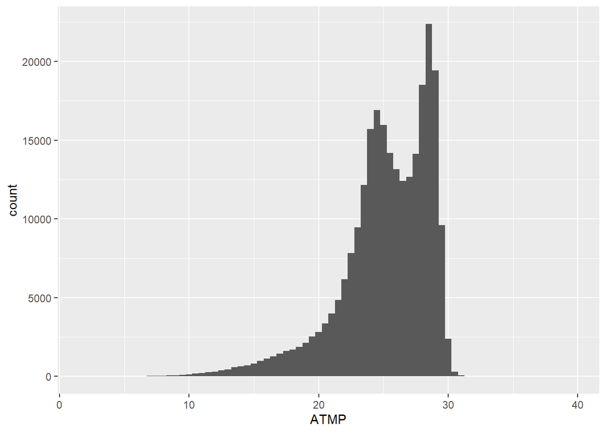

```r
# Hist. of ATMP
ggplot(data = mr_tib2) +
  geom_histogram(mapping = aes(x=ATMP),binwidth = 0.5)
```

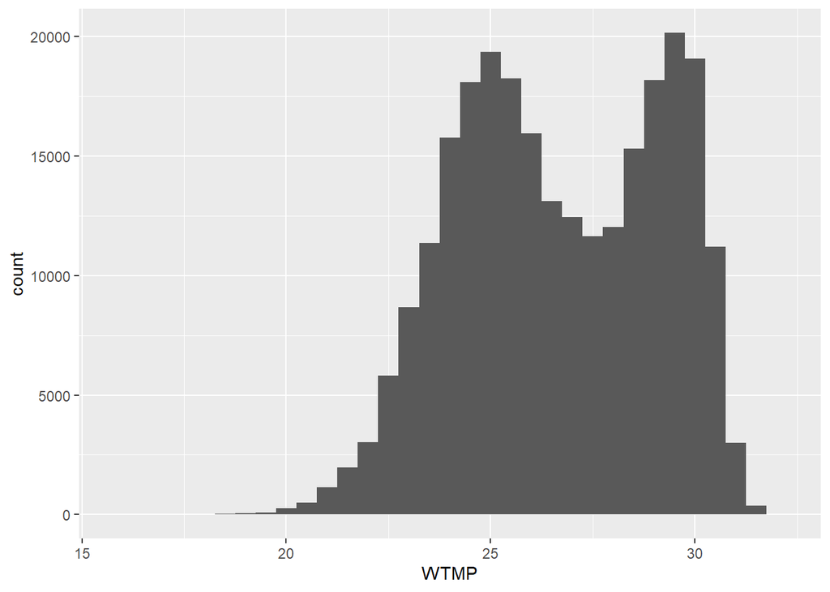

```r
# Hist. of WTMP
ggplot(data = mr_tib2) +
  geom_histogram(mapping = aes(x=WTMP),binwidth = 0.5)
```

#### 2.2.2 Conduct the Imputation

According to the plots above, we will replace NA with median.

```r
mr_tib2[is.na(mr_tib2$WD),"WD"] =
  median(mr_tib2$WD,na.rm = T)

mr_tib2[is.na(mr_tib2$WSPD),"WSPD"] =
  median(mr_tib2$WSPD,na.rm = T)

mr_tib2[is.na(mr_tib2$GST),"GST"] =
  median(mr_tib2$GST,na.rm = T)

mr_tib2[is.na(mr_tib2$ATMP),"ATMP"] =
  median(mr_tib2$ATMP,na.rm = T)

mr_tib2[is.na(mr_tib2$WTMP),"WTMP"] =
  median(mr_tib2$WTMP,na.rm = T)
```

Then we will use the summary() to check if NA still existed.

```r
# Check the NA
summary(mr_tib2)
```

```
##      YYYY                MM                 DD                 hh
##  Length:260067      Length:260067      Length:260067      Length:260067
##  Class :character   Class :character   Class :character   Class :character
##  Mode  :character   Mode  :character   Mode  :character   Mode  :character
##
##
##
##        WD           WSPD             GST              ATMP
##  Min.   :  0   Min.   : 0.000   Min.   : 0.000   Min.   : 1.80
##  1st Qu.: 80   1st Qu.: 3.800   1st Qu.: 4.300   1st Qu.:23.50
##  Median :117   Median : 5.800   Median : 6.400   Median :25.60
##  Mean   :139   Mean   : 5.969   Mean   : 6.699   Mean   :25.16
##  3rd Qu.:181   3rd Qu.: 8.000   3rd Qu.: 8.900   3rd Qu.:28.00
##  Max.   :360   Max.   :33.500   Max.   :41.000   Max.   :39.50
##       WTMP
##  Min.   :15.90
##  1st Qu.:24.70
##  Median :26.60
##  Mean   :26.67
##  3rd Qu.:29.00
##  Max.   :32.10
```

The summary indicates that no existed NA, the data can be used for further analysis.

### 2.3 Filter the Dataset

Make data type transformation on columns for Year, Month, Day and Hour.

```r
for (i in 1:4)
  suppressMessages(
    mr_tib2[,i] <- as.integer(unlist(mr_tib2[,i]))
    )
# Solve the error caused by unknown reasons
mr_tib2$YYYY[which(mr_tib2$YYYY==3899)] = 1999
```

```r
# Load the packages
library(lubridate)
library(ggpubr)
```

Sort the dataset by quarter:

```r
mr_tib2['date']<-paste(mr_tib2$YYYY,mr_tib2$MM,mr_tib2$DD,mr_tib2$hh,sep="-")
mr_tib2['date']<-ymd_h(mr_tib2$date)
q1<-subset(mr_tib2,quarter(mr_tib2$date)==1)
q2<-subset(mr_tib2,quarter(mr_tib2$date)==2)
q3<-subset(mr_tib2,quarter(mr_tib2$date)==3)
q4<-subset(mr_tib2,quarter(mr_tib2$date)==4)
```

### 2.4 Explore the Pattern

#### 2.4.1 Air Temperature Pattern

Calculate each quarter’s mean air temperature by year, and plot the patterns:

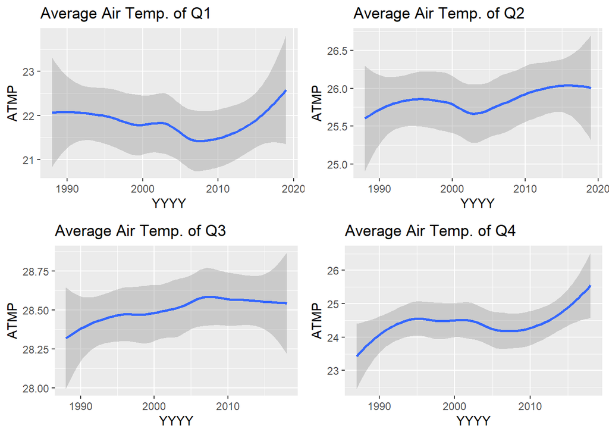

```r
# Quarter 1
meanq1<-aggregate(ATMP~YYYY,data=q1, mean)
q1reg<-ggplot(data = meanq1) +
  geom_smooth(mapping = aes(x=YYYY,y=ATMP)) +
  ggtitle("Average Air Temp. of Q1")

# Quarter 2
meanq2<-aggregate(ATMP~YYYY,data=q2, mean)
q2reg<-ggplot(data = meanq2) +
  geom_smooth(mapping = aes(x=YYYY,y=ATMP)) +
  ggtitle("Average Air Temp. of Q2")

# Quarter 3
q3reg<-meanq3<-aggregate(ATMP~YYYY,data=q3, mean)
q3reg<-ggplot(data = meanq3) +
  geom_smooth(mapping = aes(x=YYYY,y=ATMP)) +
  ggtitle("Average Air Temp. of Q3")

# Quarter 4
q4reg<-meanq4<-aggregate(ATMP~YYYY,data=q4, mean)
q4reg<-ggplot(data = meanq4) +
  geom_smooth(mapping = aes(x=YYYY,y=ATMP)) +
  ggtitle("Average Air Temp. of Q4")

# Put the plots together
ggarrange(q1reg,q2reg,q3reg,q4reg,ncol=2,nrow=2)
```

Sort the dataset by month, calculate each month’s mean air temperature by year, and plot the patterns:

```r
mname<-str_c('m',1:12)
mmean<-str_c('meanm',1:12)
mreg<-str_c('m',1:12,'reg')

for(i in 1:12){
  assign(mname[i],subset(mr_tib2,month(mr_tib2$date)==i))
  assign(mmean[i],aggregate(ATMP~YYYY,data=get(mname[i]), mean))
  assign(mreg[i],(ggplot(data = get(mmean[i])) +
  geom_smooth(mapping = aes(x=YYYY,y=ATMP)) +
  ggtitle(paste("Average Air Temp. of M",i,sep=""))))
}
```

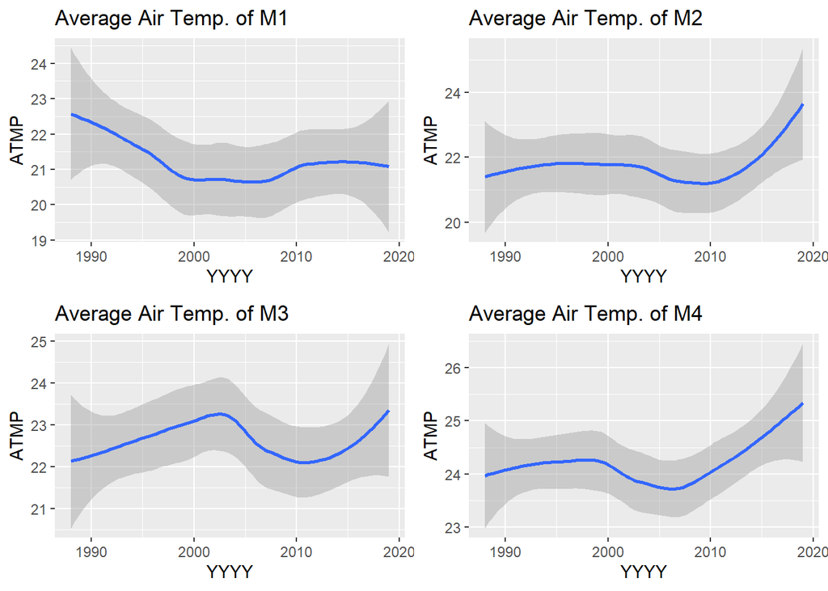

```r
# Put the plots together
ggarrange(m1reg,m2reg,m3reg,m4reg,ncol=2,nrow=2)
```

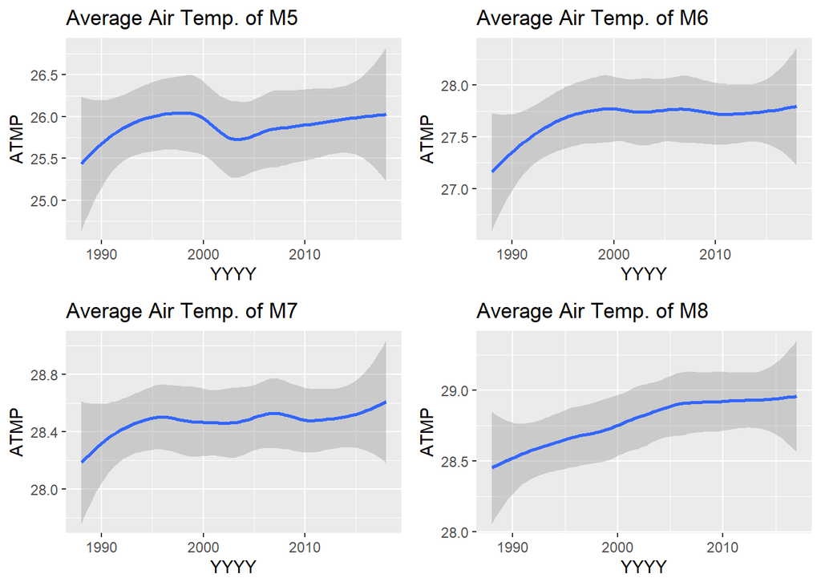

```r
ggarrange(m5reg,m6reg,m7reg,m8reg,ncol=2,nrow=2)
```

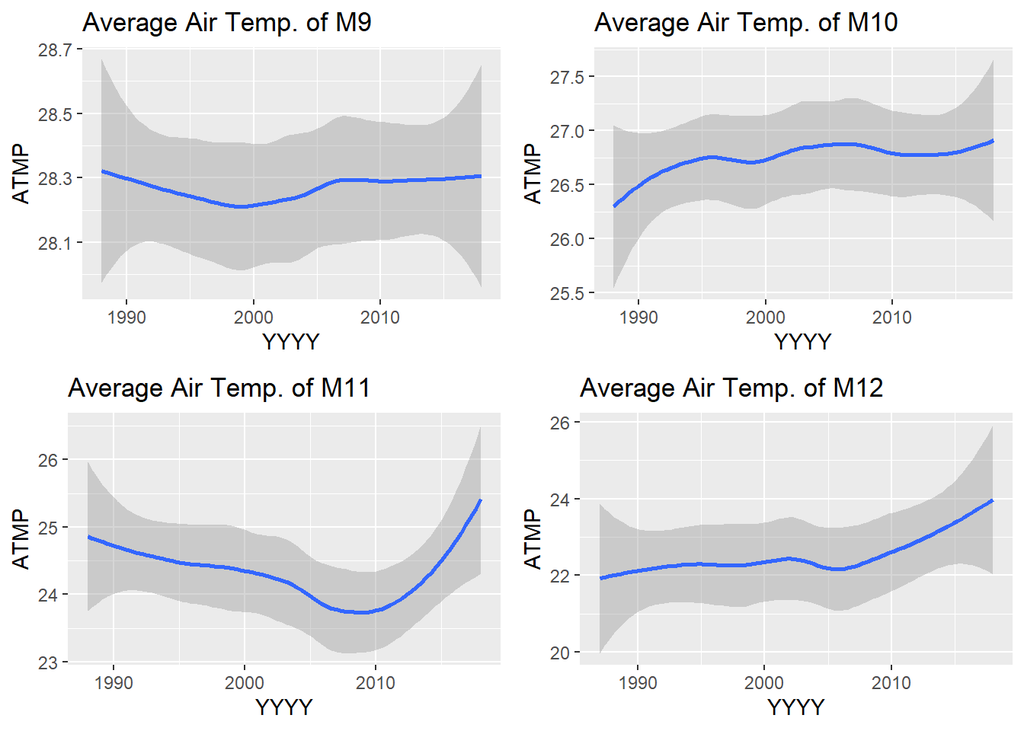

```r
ggarrange(m9reg,m10reg,m11reg,m12reg,ncol=2,nrow=2)
```

#### 2.4.2 Water Temperature Pattern

Calculate each quarter’s mean water temperature by year, and plot the patterns:

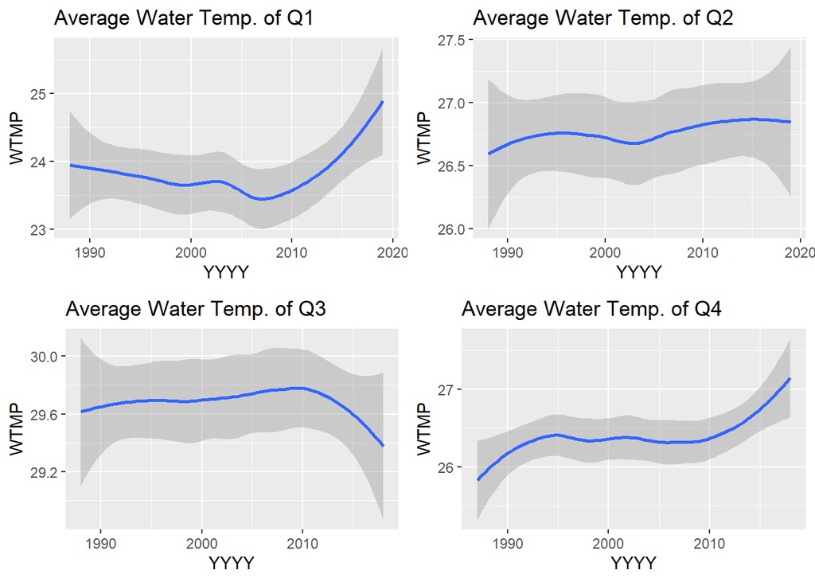

```r
# Quarter 1
meanq1_w<-aggregate(WTMP~YYYY,data=q1, mean)
q1reg_w<-ggplot(data = meanq1_w) +
  geom_smooth(mapping = aes(x=YYYY,y=WTMP)) +
  ggtitle("Average Water Temp. of Q1")

# Quarter 2
meanq2_w<-aggregate(WTMP~YYYY,data=q2, mean)
q2reg_w<-ggplot(data = meanq2_w) +
  geom_smooth(mapping = aes(x=YYYY,y=WTMP)) +
  ggtitle("Average Water Temp. of Q2")

# Quarter 3
meanq3_w<-aggregate(WTMP~YYYY,data=q3, mean)
q3reg_w<-ggplot(data = meanq3_w) +
  geom_smooth(mapping = aes(x=YYYY,y=WTMP)) +
  ggtitle("Average Water Temp. of Q3")

# Quarter 4
meanq4_w<-aggregate(WTMP~YYYY,data=q4, mean)
q4reg_w<-ggplot(data = meanq4_w) +
  geom_smooth(mapping = aes(x=YYYY,y=WTMP)) +
  ggtitle("Average Water Temp. of Q4")

# Put the plots together
ggarrange(q1reg_w,q2reg_w,q3reg_w,q4reg_w,ncol=2,nrow=2)
```

```r
mmean_w<-str_c('meanm_w',1:12)
mreg_w<-str_c('m',1:12,'reg_w')

for(i in 1:12){
  assign(mname[i],subset(mr_tib2,month(mr_tib2$date)==i))
  assign(mmean_w[i],aggregate(WTMP~YYYY,data=get(mname[i]), mean))
  assign(mreg_w[i],(ggplot(data = get(mmean_w[i])) +
  geom_smooth(mapping = aes(x=YYYY,y=WTMP)) +
  ggtitle(paste("Average Water Temp. of M",i,sep=""))))
}
```

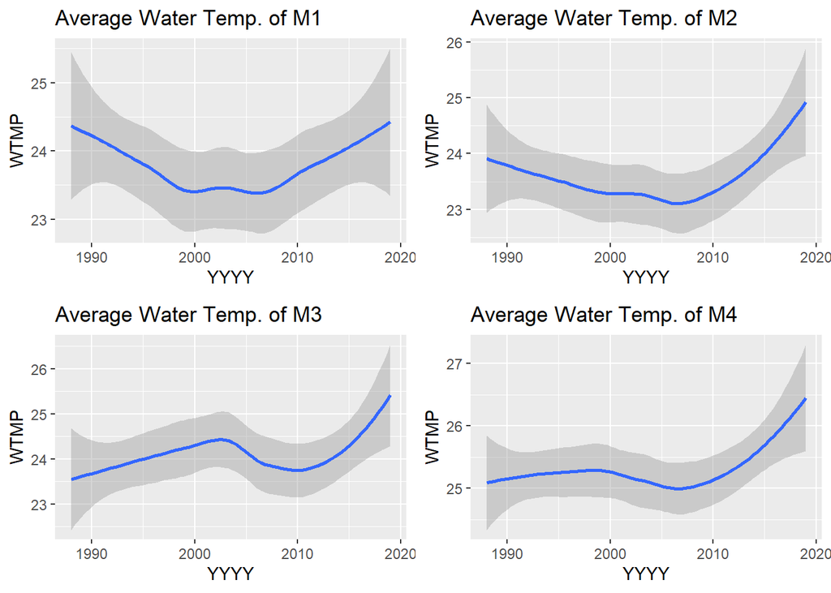

```r
# Put the plots together
ggarrange(m1reg_w,m2reg_w,m3reg_w,m4reg_w,ncol=2,nrow=2)
```

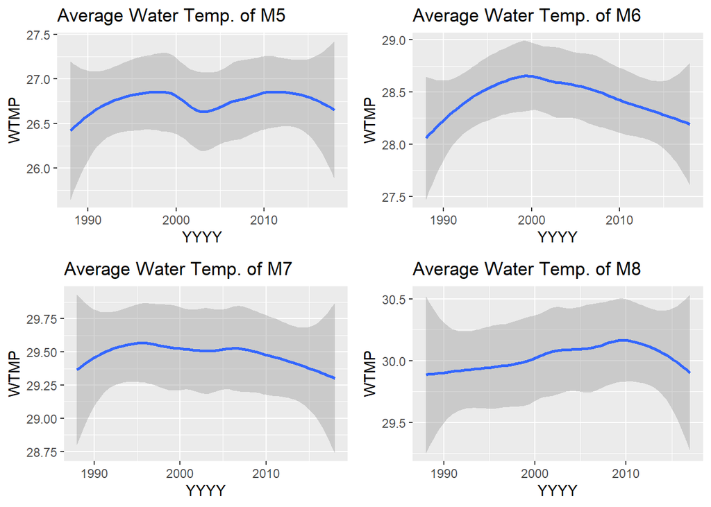

```r
ggarrange(m5reg_w,m6reg_w,m7reg_w,m8reg_w,ncol=2,nrow=2)
```

## 3 Model Analysis

Based on the result of pattern exploration in previous part, we are going to use linear model to fit the model between temperature and year.

### 3.1 Stationarity Test

First, we use ACF function to visualize the stationarity of the air and water temperature.

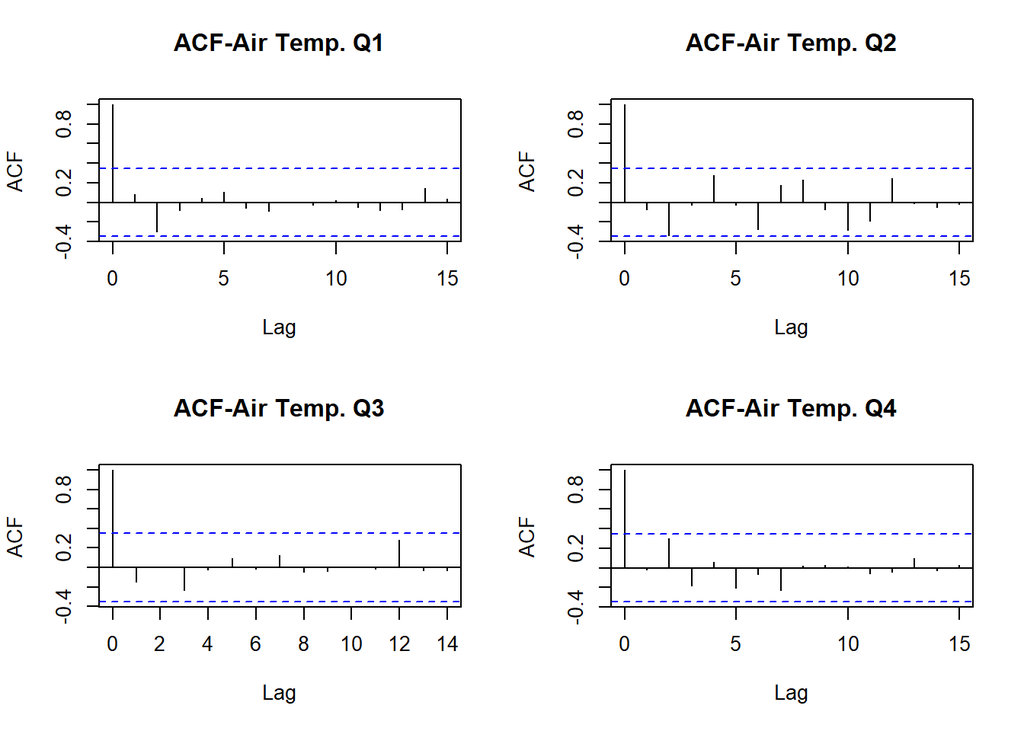

```r
# ACF of air temp.
par(mfrow=c(2,2))
acf(meanq1$ATMP,main="ACF-Air Temp. Q1")
acf(meanq2$ATMP,main="ACF-Air Temp. Q2")
acf(meanq3$ATMP,main="ACF-Air Temp. Q3")
acf(meanq4$ATMP,main="ACF-Air Temp. Q4")
```

From the ACF plots above, we can see that the pattern of air tmperature performs like white noise, so we can conclude that the time series of air temperature is stationary.

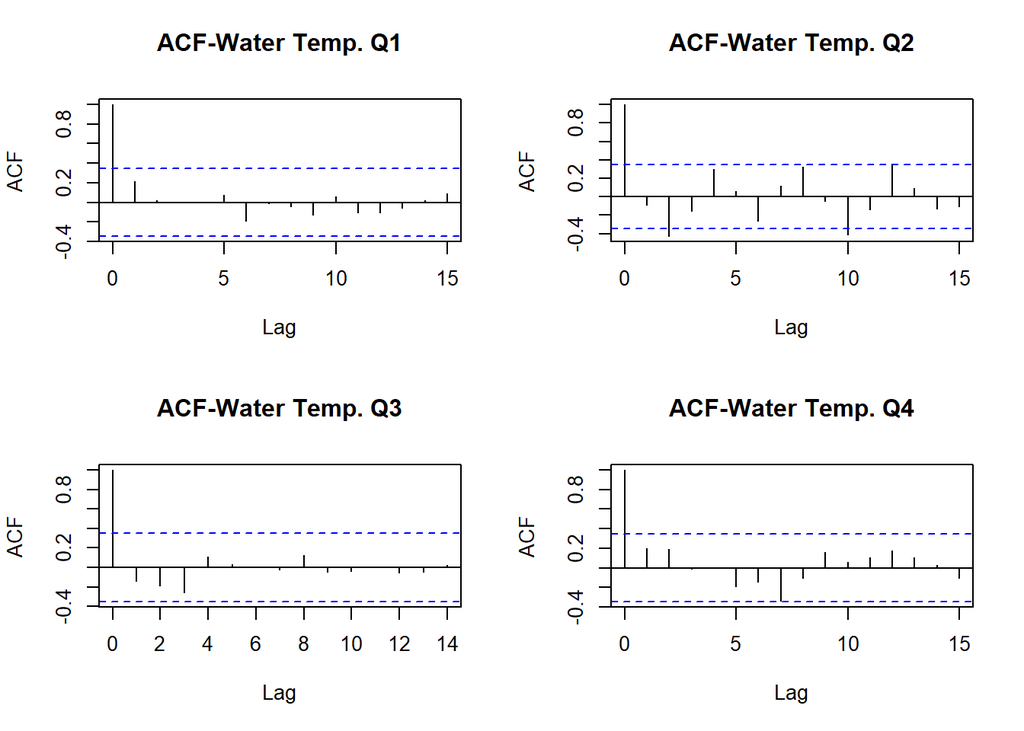

```r
# ACF of water temp.
par(mfrow=c(2,2))
acf(meanq1_w$WTMP,main="ACF-Water Temp. Q1")
acf(meanq2_w$WTMP,main="ACF-Water Temp. Q2")
acf(meanq3_w$WTMP,main="ACF-Water Temp. Q3")
acf(meanq4_w$WTMP,main="ACF-Water Temp. Q4")
```

From the ACF plots above, we can see that the pattern of water tmperature performs like white noise, so we can conclude that the time series of water temperature is stationary.

Then we can strat to bulid models on those two features.

### 3.2 Air Temperature

```r
# Fit the model of Air Temp.
air_q1 = lm(ATMP~YYYY,data = meanq1)
air_q2 = lm(ATMP~YYYY,data = meanq2)
air_q3 = lm(ATMP~YYYY,data = meanq3)
air_q4 = lm(ATMP~YYYY,data = meanq4)
```

```r
data.frame(Quarter=c("Q1","Q2","Q3","Q4"),
           Coef_AirTemp=c(air_q1$coefficients[2],
                          air_q2$coefficients[2],
                          air_q3$coefficients[2],
                          air_q4$coefficients[2])
           )
```

```
##   Quarter Coef_AirTemp
## 1      Q1 -0.004741356
## 2      Q2  0.010480319
## 3      Q3  0.006235607
## 4      Q4  0.026275834
```

### 3.3 Water Temperature

```r
# Fit the model of Air Temp.
water_q1 = lm(WTMP~YYYY,data = meanq1_w)
water_q2 = lm(WTMP~YYYY,data = meanq2_w)
water_q3 = lm(WTMP~YYYY,data = meanq3_w)
water_q4 = lm(WTMP~YYYY,data = meanq4_w)
```

```r
data.frame(Quarter=c("Q1","Q2","Q3","Q4"),
           Coef_WaterTemp=c(water_q1$coefficients[2],
                          water_q2$coefficients[2],
                          water_q3$coefficients[2],
                          water_q4$coefficients[2])
           )
```

```
##   Quarter Coef_WaterTemp
## 1      Q1    0.013315079
## 2      Q2    0.006574236
## 3      Q3   -0.002110240
## 4      Q4    0.019466770
```

### 3.4 Conclusion and Limitations

However, it seems that further information is still to be interpreted and explored, since we found out some interesting correlation between average water temperature and average air temperature.

Also, the reason behind the variation of average air temperature is valuable to be digged in.

## 4 Reference and Acknowledge

### 4.1 References

[1]Hadley Wickham, Romain François, Lionel Henry, Kirill Müller.(2020) dplyr: A Grammar of Data Manipulation, version 1.0.2

[2]Hadley Wickham.(2019) tidyverse: Easily Install and Load the ‘Tidyverse’, version 1.3.0

[3]Alboukadel Kassambara.(2020) ggpubr: ‘ggplot2’ Based Publication Ready Plots, version 0.4.0

[4]Tripti Dimri, Shamshad Ahmad and Mohammad Sharif. (2020) Time series analysis of climate variables using seasonal ARIMA approach. Journal of Earth System Science. 149 (2020)

### 4.2 Acknowledgement

We sincerely thank Prof.Haviland for helping us to obtain open source data and provide guidance for our project.